# Social Networks - Final Project

Satyam Anand

21 December 2021

## Package Installation and Read Me

### Package Management

```
  This project uses numerous packages that should be installed as specified
  below to ensure that the code runs as intended. Most packages are used to
  perform graphical manipulations on network visualizations.

  The data processing prior to the exploratory and network analysis is done
  using Python with permission from Professor James Hollway.  This code has
  been commented out in most sections for the '.html' file; however, can be
  referred to in the '.Rmd' file.

  Additionally, please note that this project assumes a basic understanding
  of the mechanics in Pokémon and familiarity with battles. Although topics
  are introduced,  further discussion is avoided unless crucial to analysis
  of the networks themselves. Additional information about such details and
  other context about the Pokemon franchise  are available in chunks marked
  accordingly and hidden in the .html file but accesible in the .Rmd file.
```

## Introduction to (Competitive) Pokémon

#### Pokémon: The Research Question

This analysis will use data from the most popular Over-Used category of Pokémon battles on Pokémon Showdown for Generation IV battles to analyse which Pokémon are the most competitively feasible options for new players embarking on their first Pokémon adventure in Sinnoh. At its core, this project aims to answer the following research question:
$$\text{How do the type, role and Generation affect the number of appearances
that two Pokémon share with each other in a team?}$$

In the words of Professor Oak from the first Pokémon games, a world of dreams and adventures with Pokémon awaits! Let’s go! [1](https://bulbapedia.bulbagarden.net/wiki/Professor_Oak/Quotes)

#### Base Statistics and Damage Categories

The indices for classification can be computed as follows: a Sweeper has higher Offensive Score than Defensive Score (opposite for Walls); the higher attribute between the Physical and Special stat determine its category classification:
$$\text{Offensive Score }_i = \frac{\max(\text{Attack} , \text{ Sp. Attack} )
+ \text{Speed}}{2}$$
$$\text{Defensive Score }_i = \frac{\max(\text{Defense}, \text{ Sp. Defense})
+ \text{HP}}{2}$$

The Pokémon in the network are plotted below such that the quadrant corresponds to the role, i.e. Quadrant 1 (in top-right) contains Special Sweepers and so on for the other roles as well. Colors denote Pokémon types whereas size represent the relative usage across battles.

Attribute data obtained from user Armgilles on [Github](https://gist.githubusercontent.com/armgilles/)

Colorscheme from user APaleSlimGhose on [Github](https://gist.github.com/apaleslimghost/)

[figure not shown]

#### Hypotheses

Similar traits are counterproductive in Pokémon teams and heterophily should be present in the networks as Pokémon connect to others who can counter threats. That being said, since these remakes carry nostalgia, teams may be built around Pokémon from the same generations. Hence, homophily may exist among Pokémon who were introduced in the same generation.

#### Exploratory Statistics and Visualizations

The following graphs summarizes type match-ups and the distribution of types in the competitive Pokémon as well as pair-wise base statistics.

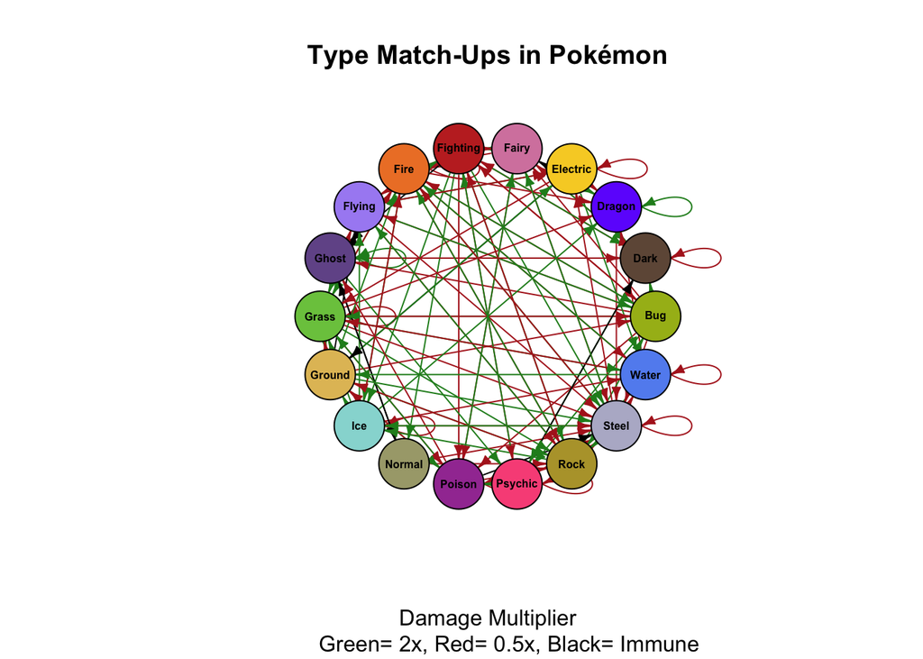

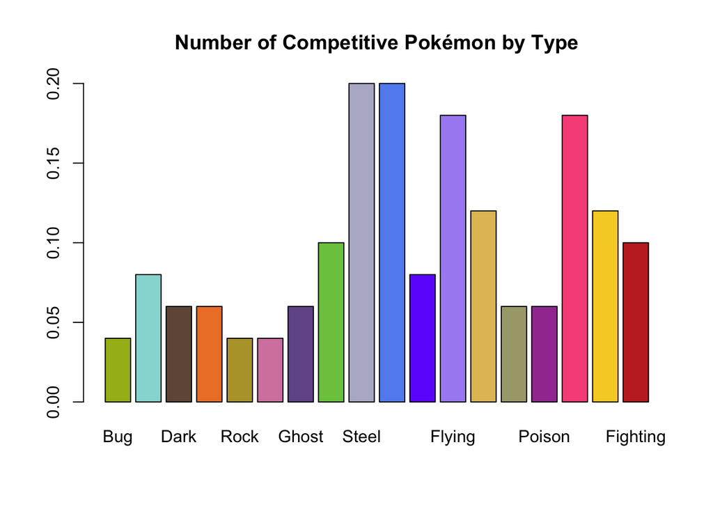

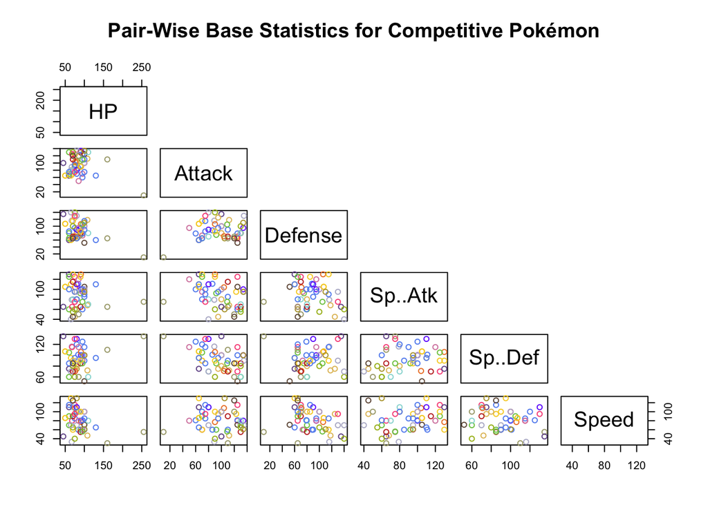

## Network Analysis

#### Network Initialization and Basic Visualization

Having extensively discussed the mechanics in competitive Pokémon, the network for competitive Pokémon in the Over-Used category for November 2021 can finally be visualized. Recall that tie between Pokémon X and Pokémon Y in this network indicates that the partnership between these Pokémon ranks among top quartile.

[figure not shown]

#### Fundamental Characteristics

[figure not shown]

Hence, Tyranitar, Jirachi and Latias are the most popular partners across teams whereas three main communities exist that were built using a WalkTrap algorithm chosen due to compatiblity with weighted graphs with step-size at default=4 as recommended by Pons and Lapaty [3](https://arxiv.org/abs/physics/0512106).

### Multiple Regression Quadratic Assignment Procedure (MQARP)

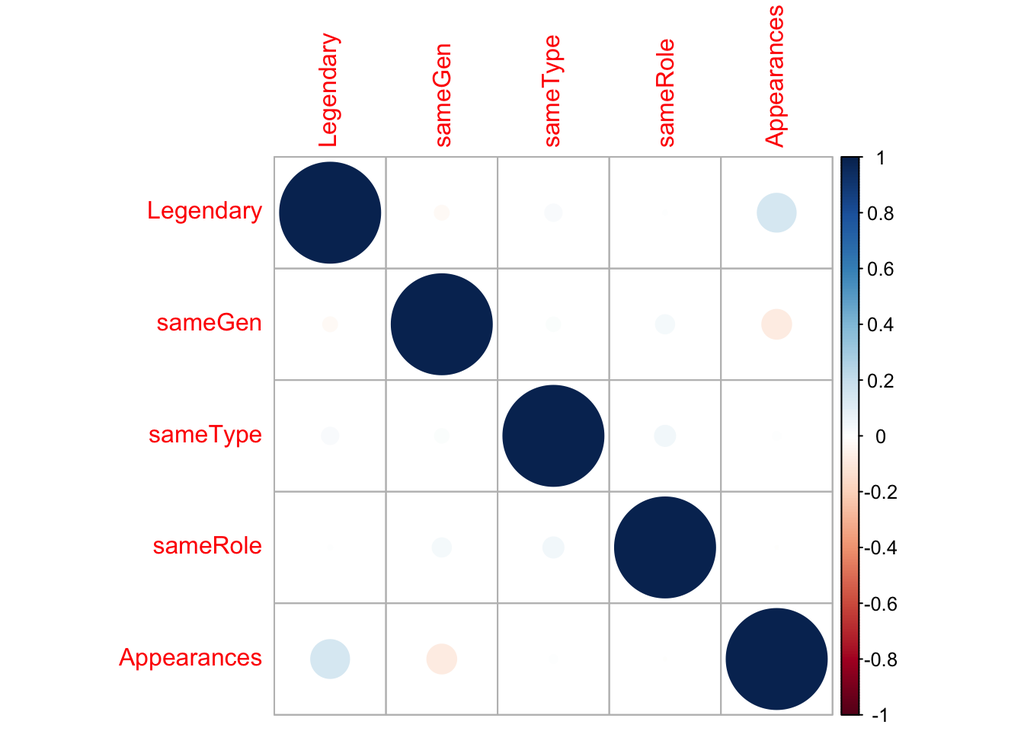

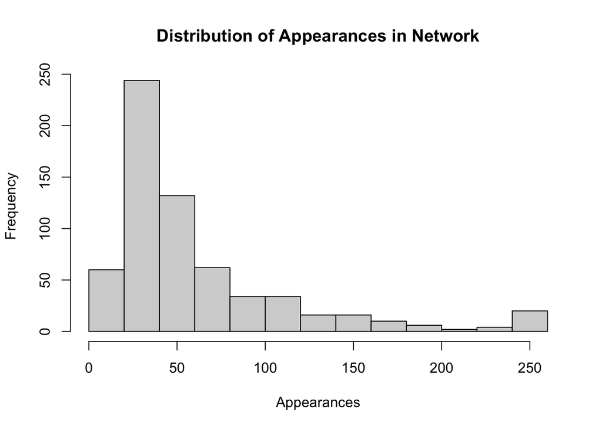

```r
# Model 1: Same Generation (naive model using only Generation)
Model      <- list(sameGen    = sameGen)
result1    <- sna::netlm(apps_network, Model)

# Adjusted R-squared: 0.00781
#              *  Estimate   *  Pr(>=|b|)  *
# ******************************************
# (intercept)  *  18.515216  *  0.000      *
# sameGen      *  -8.197961  *  0.054*     *


# Model 2: Same Role, Type and Generation (competitive model)
Model[[2]] <- sameType
Model[[3]] <- sameRole
result2    <- sna::netlm(apps_network, Model)

# Adjusted R-squared: 0.007085
#              *  Estimate    *  Pr(>=|b|)  *
# *******************************************
# (intercept)  *  18.6872492  *  0.000      *
# sameGen      *  -8.1904564  *  0.058*     *
# sameType     *   0.4481490  *  0.915      *
# sameRole     *  -0.5212931  *  0.773      *



# Model 3: Legendary Status; Same Role, Type and Generation
Model[[4]] <- Legendary
Model[[5]] <- Legendary %>% t()
result3    <- sna::netlm(apps_network, Model)

# Adjusted R-squared: 0.0496
#              *  Estimate    *  Pr(>=|b|)  *
# *******************************************
# (intercept)  *  13.7485409  *  0.000      *
# sameGen      *  -7.6251750  *  0.059*     *
# sameType     *  -0.4599335  *  0.893      *
# sameRole     *  -0.5537914  *  0.791      *
# Legendary    *  18.0355946  *  0.036**    *
# LegendaryT   *  18.0355946  *  0.027**    *
```

Thus, based on the MRQAP regressions, the number of joint appearances among the Top 25% Pokemon partnerships is significantly affected on the dyad level by the Pokémon belonging to the same Generation in a negative manner (contrary to the null hypothesis). This result was significant at 10% significance level in all three model configurations and is small compared to appearances’ distribution within the network, which is right-tailed with median around 40.

In terms of monadic properties, the regression found that Legendary Pokémon are more likely to have higher appearance counts as per the 3rd model configuration with a result that is significant at $\alpha = 0.05$, The coefficient suggests that legendary Pokémon will have around 18 more appearances than their common counterparts; this is most likely due to their higher base stats that increases their popularity in competitions.

Lastly, all three models have rather low adjusted R-square values; however, the including the Legendary variable in last configuration substantially raises the R-squared value from less than 0.01 to almost 0.05.